# Keşifsel Analiz

Prof. Dr. H. Kemal İlter

IZV 701

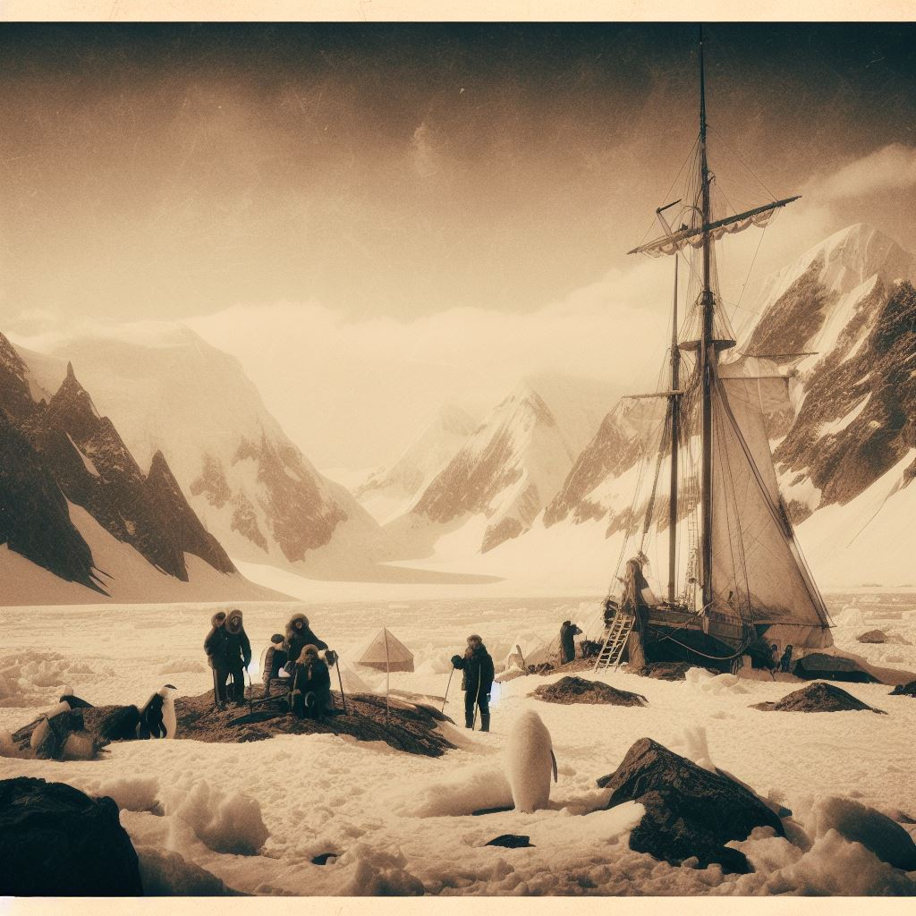

Amundsen, 1911. DALL-E 3

## 1. Kategorik Değişkenler

### Soru

Chicago Üniversitesi’nde bulunan Ulusal Araştırma Görüş Merkezi (NORC), 1972’den bu yana Genel Sosyal Anketi (GSS) yürütmektedir. Anketin amacı, toplumsal değişimi izlemek ve Amerikan toplumunun artan karmaşıklığını incelemektir. Kişisel tanımlayıcılar arasında yaş, ırk, cinsiyet, medeni durum, gelir, eğitim, siyasi parti ve dini bağlantı gibi özellikler bulunmaktadır. **2000 ile 2014 yılları arasında GSS’ye yanıt verenler arasında medeni durum ve gelir dağılımı nasıldı?**

```r
#load tidyverse library
library(tidyverse)
```

### Veri

```r
#import GSS data
data(gss_cat)

#review data structure
str(gss_cat)
```

```
## tibble [21,483 × 9] (S3: tbl_df/tbl/data.frame)
##  $ year   : int [1:21483] 2000 2000 2000 2000 2000 2000 2000 2000 2000 2000 ...
##  $ marital: Factor w/ 6 levels "No answer","Never married",..: 2 4 5 2 4 6 2 4 6 6 ...
##  $ age    : int [1:21483] 26 48 67 39 25 25 36 44 44 47 ...
##  $ race   : Factor w/ 4 levels "Other","Black",..: 3 3 3 3 3 3 3 3 3 3 ...
##  $ rincome: Factor w/ 16 levels "No answer","Don't know",..: 8 8 16 16 16 5 4 9 4 4 ...
##  $ partyid: Factor w/ 10 levels "No answer","Don't know",..: 6 5 7 6 9 10 5 8 9 4 ...
##  $ relig  : Factor w/ 16 levels "No answer","Don't know",..: 15 15 15 6 12 15 5 15 15 15 ...
##  $ denom  : Factor w/ 30 levels "No answer","Don't know",..: 25 23 3 30 30 25 30 15 4 25 ...
##  $ tvhours: int [1:21483] 12 NA 2 4 1 NA 3 NA 0 3 ...
```

```r
#select two columns and omit rows with missing data
gss_cat2 <- gss_cat %>%
  select(marital,rincome) %>%
  na.omit()

#show levels of marital status
levels(gss_cat2$marital)
```

```
## [1] "No answer"     "Never married" "Separated"     "Divorced"
## [5] "Widowed"       "Married"
```

```r
#show levels of income
levels(gss_cat2$rincome)
```

```
##  [1] "No answer"      "Don't know"     "Refused"        "$25000 or more"
##  [5] "$20000 - 24999" "$15000 - 19999" "$10000 - 14999" "$8000 to 9999"
##  [9] "$7000 to 7999"  "$6000 to 6999"  "$5000 to 5999"  "$4000 to 4999"
## [13] "$3000 to 3999"  "$1000 to 2999"  "Lt $1000"       "Not applicable"
```

```r
#combine and rename income levels
gss_cat3 <- gss_cat2 %>%
  mutate(rincome2=fct_collapse(rincome,
                   missing=c("No answer","Don't know","Refused","Not applicable"),
                   under_5=c("Lt $1000","$1000 to 2999","$3000 to 3999","$4000 to 4999"),
                   from_5to10=c("$5000 to 5999","$6000 to 6999","$7000 to 7999","$8000 to 9999"),
                   from_10to15="$10000 - 14999",
                   from_15to20="$15000 - 19999",
                   from_20to25="$20000 - 24999",
                   over_25="$25000 or more")) %>%
  select(-rincome)

#show new levels of income
levels(gss_cat3$rincome2)
```

```
## [1] "missing"     "over_25"     "from_20to25" "from_15to20" "from_10to15"
## [6] "from_5to10"  "under_5"
```

```r
#reorder income levels
gss_cat4 <- gss_cat3 %>%
  mutate(rincome2=fct_relevel(rincome2,
                   c("missing","under_5","from_5to10","from_10to15","from_15to20",
                     "from_20to25","over_25")))

#show new categories of income
levels(gss_cat4$rincome2)
```

```
## [1] "missing"     "under_5"     "from_5to10"  "from_10to15" "from_15to20"
## [6] "from_20to25" "over_25"
```

### Analiz

```r
#summarize variables
summary(gss_cat4)
```

```
##           marital             rincome2
##  No answer    :   17   missing    :8468
##  Never married: 5416   under_5    :1183
##  Separated    :  743   from_5to10 : 970
##  Divorced     : 3383   from_10to15:1168
##  Widowed      : 1807   from_15to20:1048
##  Married      :10117   from_20to25:1283
##                        over_25    :7363
```

```r
#compute income level percentages
gss_cat4 %>%
  group_by(rincome2) %>%
  summarize(count=n()) %>%
  mutate(prop=count/sum(count)) %>%
  ungroup()
```

```
## # A tibble: 7 × 3
##   rincome2    count   prop
##   <fct>       <int>  <dbl>
## 1 missing      8468 0.394
## 2 under_5      1183 0.0551
## 3 from_5to10    970 0.0452
## 4 from_10to15  1168 0.0544
## 5 from_15to20  1048 0.0488
## 6 from_20to25  1283 0.0597
## 7 over_25      7363 0.343
```

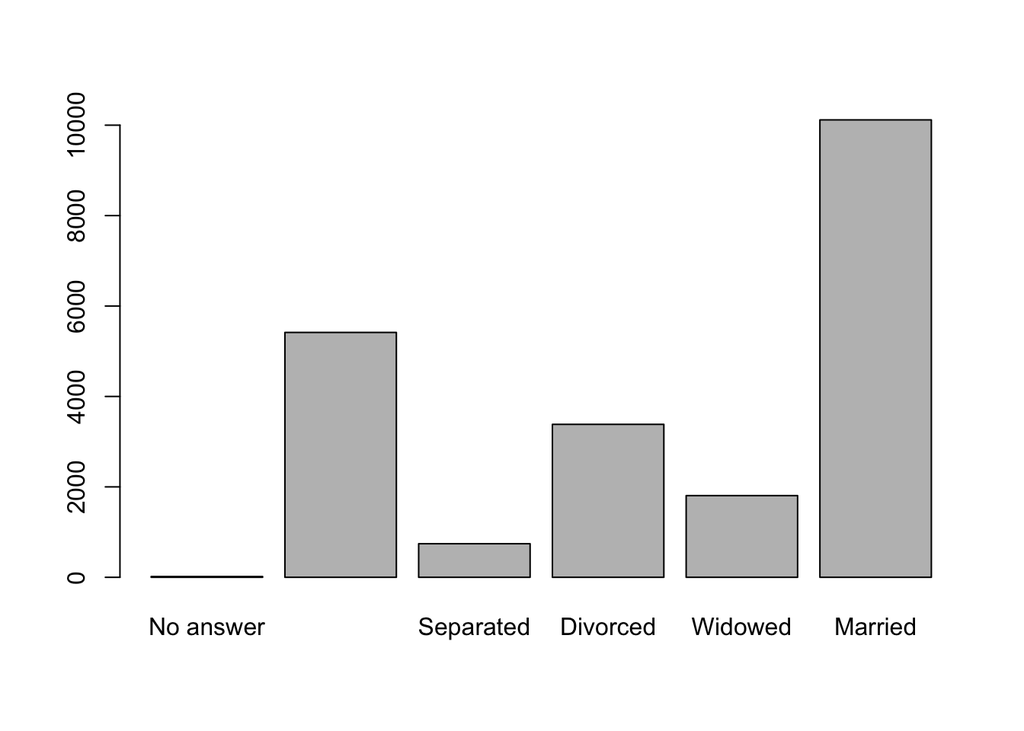

```r
#plot basic bar chart of marital status
plot(gss_cat4$marital)
```

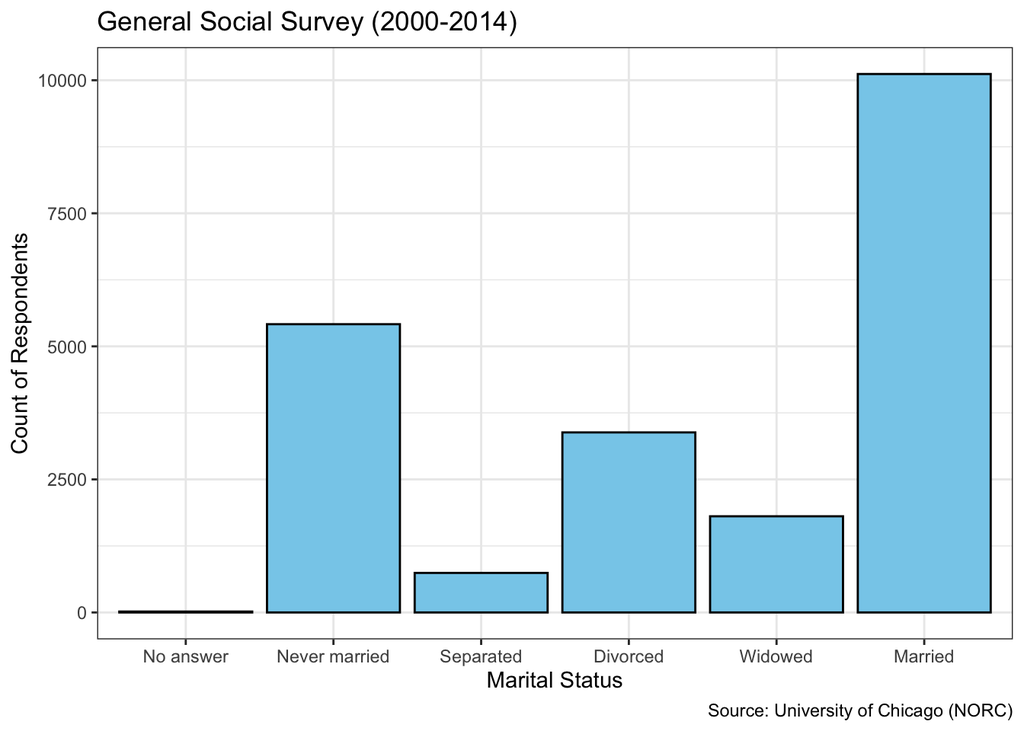

```r
#plot ggplot2 bar chart of marital status
ggplot(data=gss_cat4,aes(x=marital)) +
  geom_bar(color="black",fill="sky blue") +
  labs(title="General Social Survey (2000-2014)",
       x="Marital Status",
       y="Count of Respondents",
       caption="Source: University of Chicago (NORC)") +
  theme_bw()
```

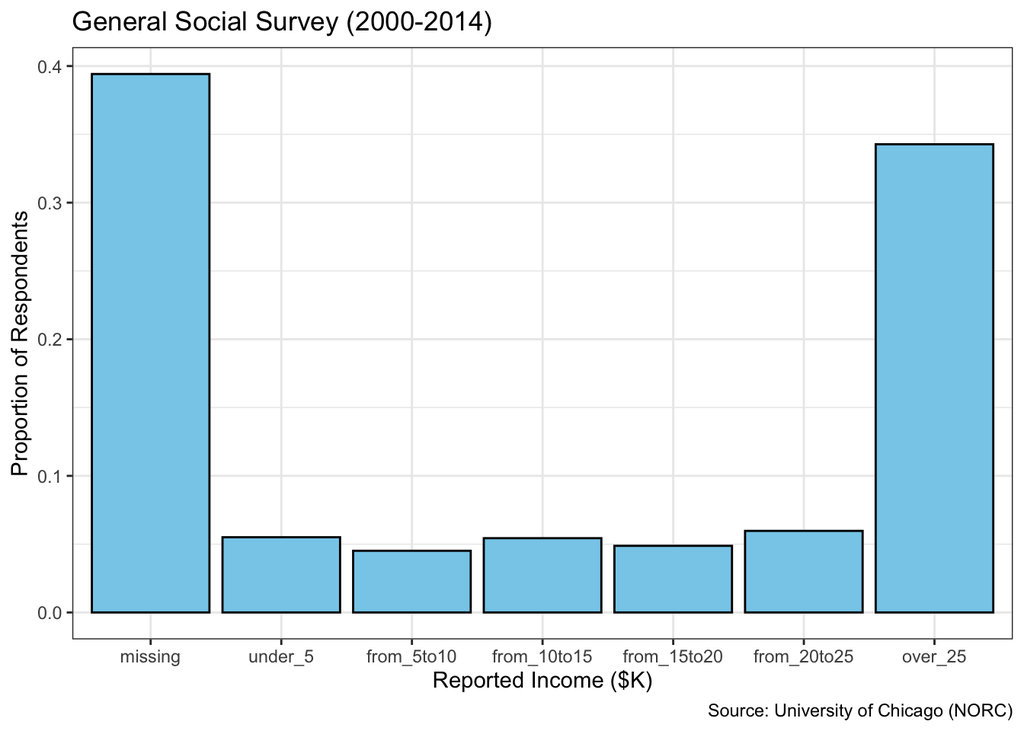

```r
#plot ggplot2 bar chart of income
ggplot(data=gss_cat4,aes(x=rincome2)) +
  geom_bar(aes(y=after_stat(prop),group=1),
           color="black",fill="sky blue") +
  labs(title="General Social Survey (2000-2014)",
       x="Reported Income ($K)",
       y="Proportion of Respondents",
       caption="Source: University of Chicago (NORC)") +
  theme_bw()
```

### Değerlendirme

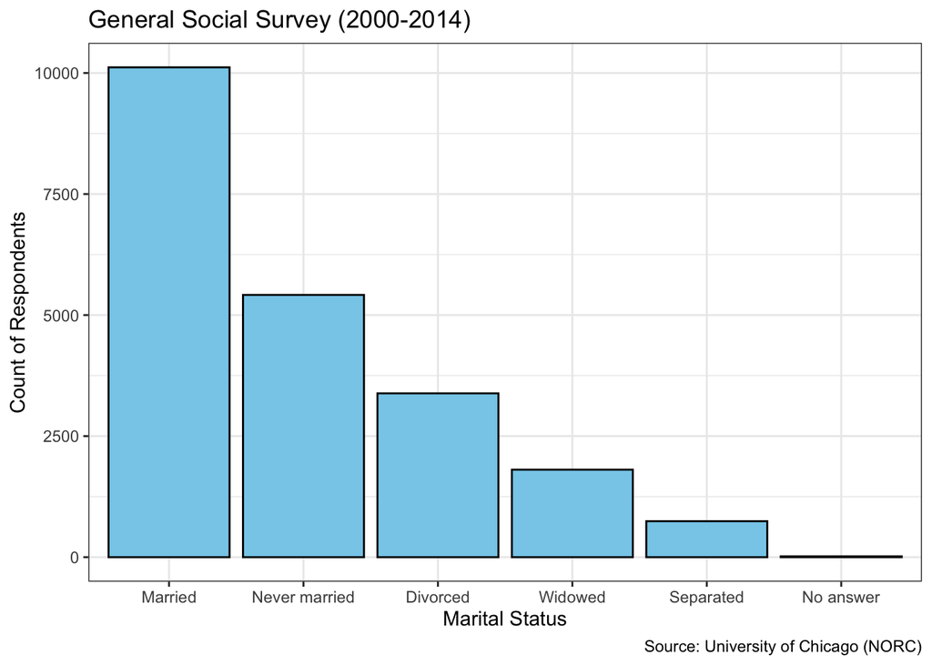

```r
#plot descending bar chart of marital status
ggplot(data=gss_cat4,aes(x=fct_infreq(marital))) +
  geom_bar(color="black",fill="sky blue") +
  labs(title="General Social Survey (2000-2014)",
       x="Marital Status",
       y="Count of Respondents",
       caption="Source: University of Chicago (NORC)") +
  theme_bw()
```

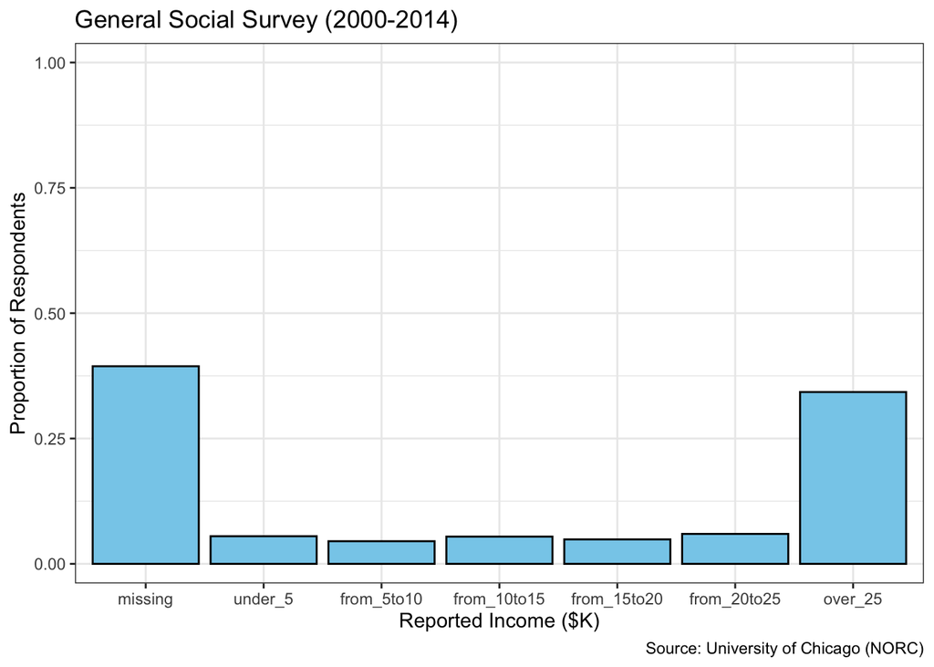

```r
#plot misleading bar chart of income
ggplot(data=gss_cat4,aes(x=rincome2)) +
  geom_bar(aes(y=after_stat(prop),group=1),
           color="black",fill="sky blue") +
  labs(title="General Social Survey (2000-2014)",
       x="Reported Income ($K)",
       y="Proportion of Respondents",
       caption="Source: University of Chicago (NORC)") +
  theme_bw() +
  coord_cartesian(ylim = c(0.01,0.99))
```

## 2. Çaprazlık Tablosu (Contingency Table)

### Soru

GSS verilerini kullanarak, daha önce Amerikalılar arasında medeni durumun bireysel dağılımını inceledik. Ancak, medeni durum ve diğer demografik faktörler arasındaki ilişki de ilgimizi çekebilir. **2000 ile 2014 yılları arasında GSS’ye yanıt verenler arasında medeni durum ile siyasi parti arasında bir ilişki var mı?**

### Veri

```r
#import GSS data
data(gss_cat)

#review marital levels
levels(gss_cat$marital)
```

```
## [1] "No answer"     "Never married" "Separated"     "Divorced"
## [5] "Widowed"       "Married"
```

```r
#review political levels
levels(gss_cat$partyid)
```

```
##  [1] "No answer"          "Don't know"         "Other party"
##  [4] "Strong republican"  "Not str republican" "Ind,near rep"
##  [7] "Independent"        "Ind,near dem"       "Not str democrat"
## [10] "Strong democrat"
```

```r
#wrangle GSS data
gss_cat2 <- gss_cat %>%
  select(marital,partyid) %>%
  na.omit() %>%
  filter(marital != "No answer",
         !partyid %in% c("No answer","Don't know","Other party")) %>%
  transmute(marital=case_when(
      marital=="Married" ~ "Now",
      marital %in% c("Separated","Divorced","Widowed") ~ "Before",
      marital=="Never married" ~ "Never"),
    political=case_when(
      partyid %in% c("Strong republican","Not str republican") ~ "Republican",
      partyid %in% c("Ind,near rep","Independent","Ind,near dem") ~ "Independent",
      partyid %in% c("Strong democrat","Not str democrat") ~ "Democrat")) %>%
  mutate(marital=as.factor(marital),
         political=as.factor(political))

#summarize data frame
summary(gss_cat2)
```

```
##    marital           political
##  Before:5774   Democrat   :7177
##  Never :5264   Independent:8403
##  Now   :9885   Republican :5343
```

### Analiz

```r
#create contingency table
table(gss_cat2$marital,
      gss_cat2$political)
```

```
##
##          Democrat Independent Republican
##   Before     2252        2237       1285
##   Never      1975        2406        883
##   Now        2950        3760       3175
```

### Değerlendirme

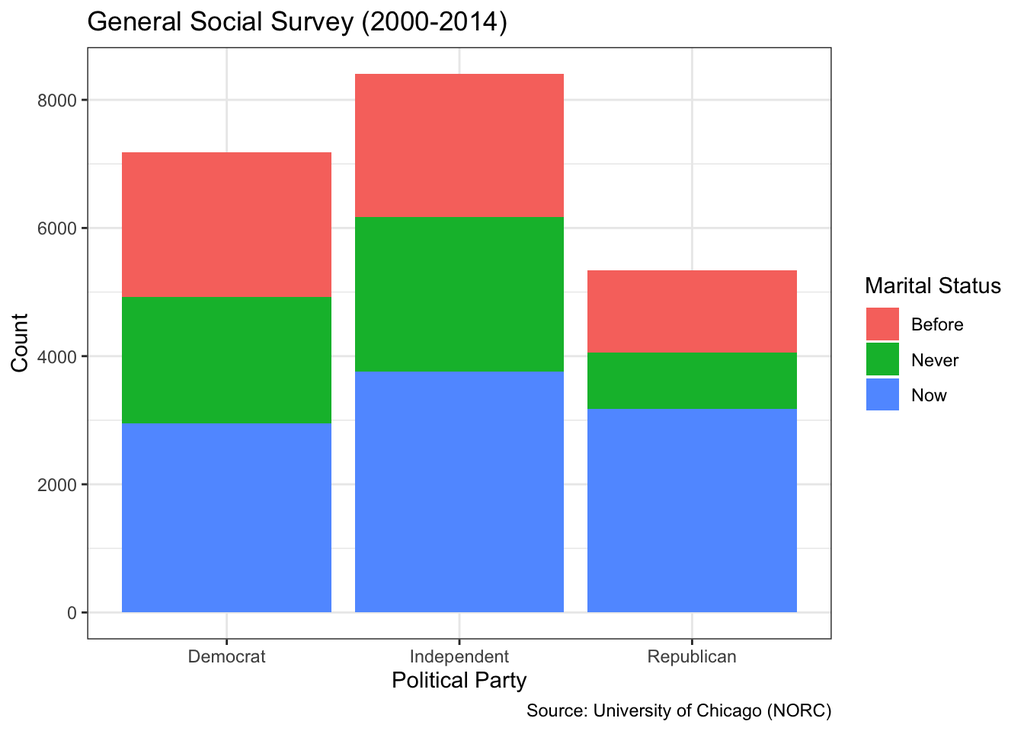

```r
#create stacked bar chart
ggplot(data=gss_cat2,aes(x=political,fill=marital)) +
  geom_bar() +
  labs(title="General Social Survey (2000-2014)",
       x="Political Party",
       y="Count",
       fill="Marital Status",
       caption="Source: University of Chicago (NORC)") +
  theme_bw()
```

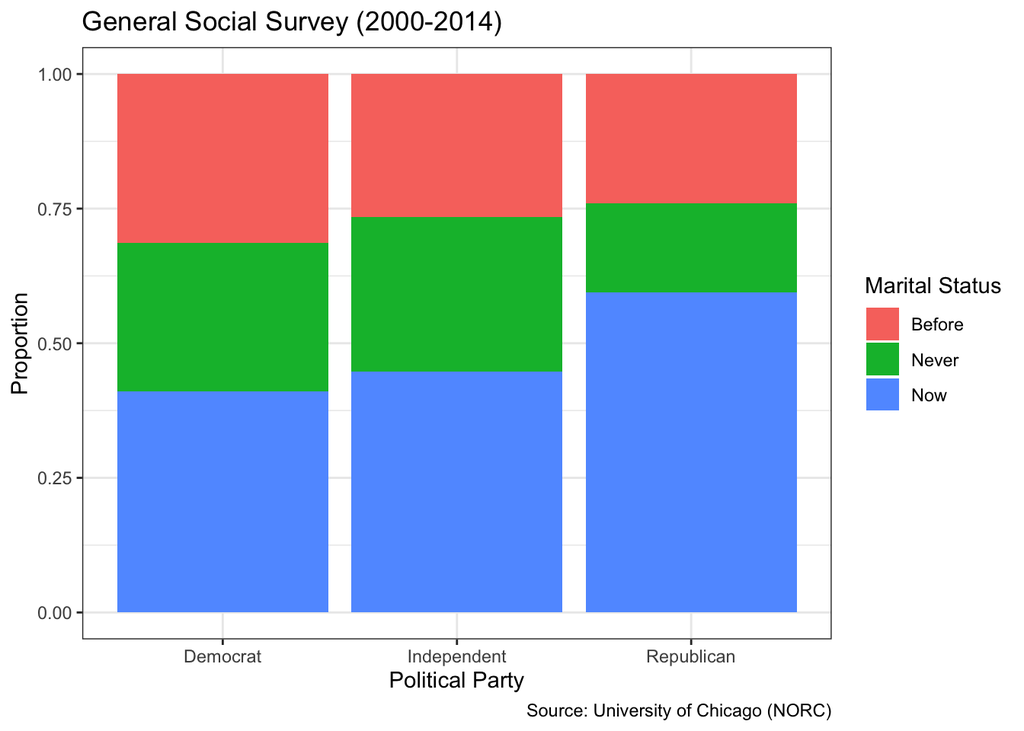

```r
#create standardized stacked bar chart
ggplot(data=gss_cat2,aes(x=political,fill=marital)) +
  geom_bar(position="fill") +
  labs(title="General Social Survey (2000-2014)",
       x="Political Party",
       y="Proportion",
       fill="Marital Status",
       caption="Source: University of Chicago (NORC)") +
  theme_bw()
```

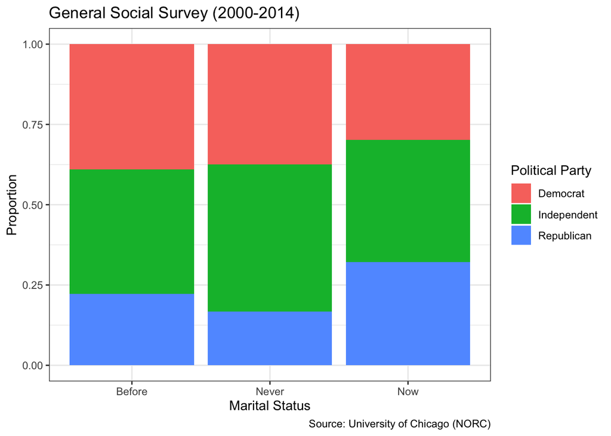

```r
#create standardized stacked bar chart
ggplot(data=gss_cat2,aes(x=marital,fill=political)) +
  geom_bar(position="fill") +
  labs(title="General Social Survey (2000-2014)",
       x="Marital Status",
       y="Proportion",
       fill="Political Party",
       caption="Source: University of Chicago (NORC)") +
  theme_bw()
```

### Yanıt

2000 ile 2014 yılları arasında GSS’ye yanıt verenler arasında, medeni durum ile siyasi parti arasında bir ilişki olduğu görülüyor. Cumhuriyetçiler arasında şu anda evli olanların oranı, diğer iki partiden daha yüksek. Öte yandan, medeni durumun dağılımı Bağımsızlar ve Demokratlar için yaklaşık olarak aynı görünüyor. Ters perspektiften bakıldığında, şu anda evli olanlar, evli olmayanlara (veya hiç olmamış olanlara) göre daha sık Cumhuriyetçi görünüyor. Her iki şekilde de bakıldığında, bu iki faktör ilişkilidir.

Cevabımız, kapsam 2000 ile 2014 yılları arasında sınırlı kaldığı sürece, orijinal soruyla iyi bir uyum içindedir. Ancak, siyasi iklimdeki, sosyal normlardaki ve ekonomik faktörlerdeki değişiklikler, analizimizin sonuçlarını değiştirebilir. Sonuç olarak, tavsiyemiz büyük ölçüde değişebilir. Güncel bir politik kampanyanın yöneticisi için, en güncel rehberliğe erişim kritik öneme sahiptir. Aynı anket sorularına modern yanıtlar sağlandığında, analizimizi kolayca tekrarlayabilir ve yeni içgörüler sunabiliriz.

## 3. Metin Madenciliği

```r
#load tidyverse and tidytext libraries
library(tidyverse)
library(tidytext)
```

### Soru

Bu vaka çalışmasında, Lewis Carroll (Carroll 1865) tarafından yazılan klasik roman Alice Harikalar Diyarında’yı inceliyoruz. Carroll’ın gerçek adı Charles Lutwidge Dodgson’dı ve Oxford Üniversitesi’nde matematikçi olarak görev yapmanın yanı sıra yazar ve şairdi. Çalışmalarını özellikle geometri, doğrusal cebir ve matematiksel mantık alanlarında yürüttü. Ancak, birçok animasyon ve canlı aksiyon filmine ilham veren bu kitabın yazarı olarak en çok tanınır. **Alice Harikalar Diyarında adlı eserde kelime kullanımı ve duygu dağılımı nasıldır?**

### Veri

```r
#import text file
alice <- read_delim("alice.txt",delim=" ",col_names=FALSE)
#display text structure
glimpse(alice)
```

```
## Rows: 2,477
## Columns: 2
## $ X1 <chr> "CHAPTER", "Down", "Alice", "bank,", "the", "conversations", "“with…
## $ X2 <chr> "I.", "the Rabbit-Hole", "was beginning to get very tired of sittin…
```

```r
#clean text file
alice2 <- alice %>%
  unite("text",X1:X2,sep=" ",na.rm=TRUE) %>%
  mutate(text=str_squish(text)) %>%
  filter(!str_detect(text,"\\*")) %>%
  transmute(line=1:2468,text)

#display structure of clean data
glimpse(alice2)
```

```
## Rows: 2,468
## Columns: 2
## $ line <int> 1, 2, 3, 4, 5, 6, 7, 8, 9, 10, 11, 12, 13, 14, 15, 16, 17, 18, 19…
## $ text <chr> "CHAPTER I.", "Down the Rabbit-Hole", "Alice was beginning to get…
```

```r
#tokenize text file by word
alice3 <- alice2 %>%
  unnest_tokens(output=word,input=text,token="words")

#display tokenized structure
glimpse(alice3)
```

```
## Rows: 26,687
## Columns: 2
## $ line <int> 1, 1, 2, 2, 2, 2, 3, 3, 3, 3, 3, 3, 3, 3, 3, 3, 3, 3, 3, 3, 4, 4,…
## $ word <chr> "chapter", "i", "down", "the", "rabbit", "hole", "alice", "was", …
```

### Analiz

```r
#count word frequency
alice3 %>%
  count(word,sort=TRUE) %>%
  head(n=10)
```

```
## # A tibble: 10 × 2
##    word      n
##    <chr> <int>
##  1 the    1643
##  2 and     871
##  3 to      729
##  4 a       632
##  5 she     538
##  6 it      527
##  7 of      514
##  8 said    460
##  9 i       393
## 10 alice   386
```

```r
#load stop words
data(stop_words)

#remove stop words
alice4 <- alice3 %>%
  anti_join(stop_words,by="word")

#count frequency without stop words
alice4 %>%
  count(word,sort=TRUE) %>%
  head(n=10)
```

```
## # A tibble: 10 × 2
##    word        n
##    <chr>   <int>
##  1 alice     386
##  2 time       71
##  3 queen      68
##  4 king       61
##  5 don’t      60
##  6 it’s       57
##  7 i’m        56
##  8 mock       56
##  9 turtle     56
## 10 gryphon    55
```

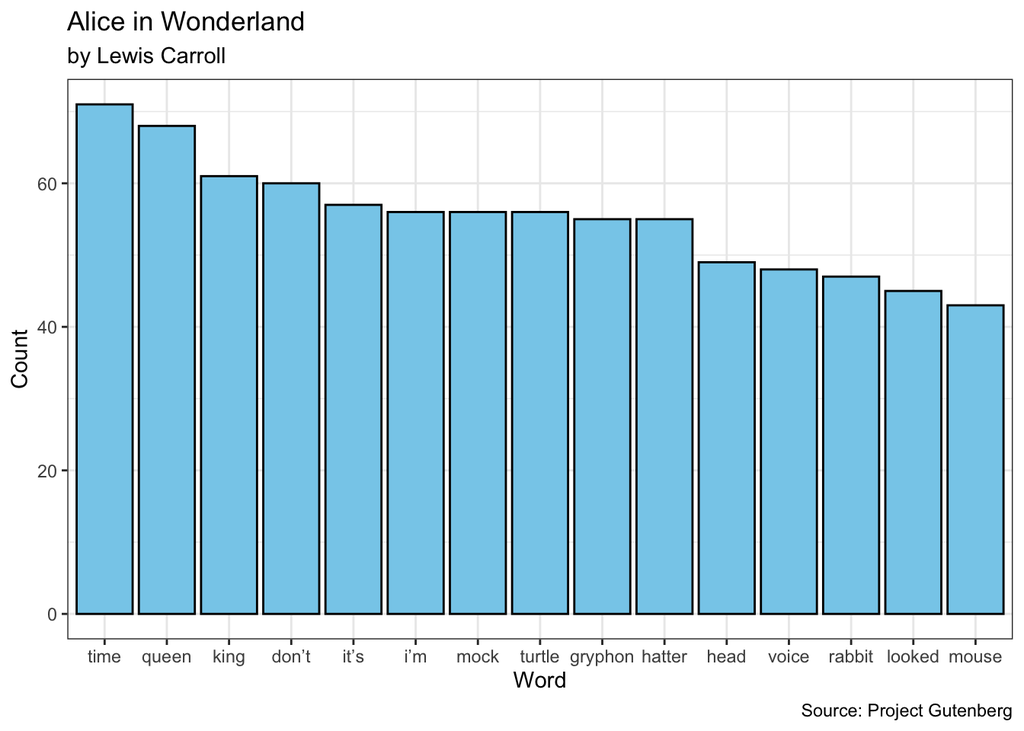

```r
#plot bar chart of word frequency
alice4 %>%
  filter(word!="alice") %>%
  count(word,sort=TRUE) %>%
  head(n=15) %>%
ggplot(aes(x=reorder(word,-n),y=n)) +
  geom_bar(color="black",fill="sky blue",
           stat="identity") +
  labs(title="Alice in Wonderland",
       subtitle="by Lewis Carroll",
       x="Word",
       y="Count",
       caption="Source: Project Gutenberg") +
  theme_bw()
```

```r
#import sentiment data
sentiments <- get_sentiments("bing")

#join sentiments to words
alice5 <- alice4 %>%
  inner_join(sentiments,by="word")

#summarize sentiments
alice5 %>%
  group_by(sentiment) %>%
  summarize(count=n()) %>%
  ungroup()
```

```
## # A tibble: 2 × 2
##   sentiment count
##   <chr>     <int>
## 1 negative    729
## 2 positive    335
```

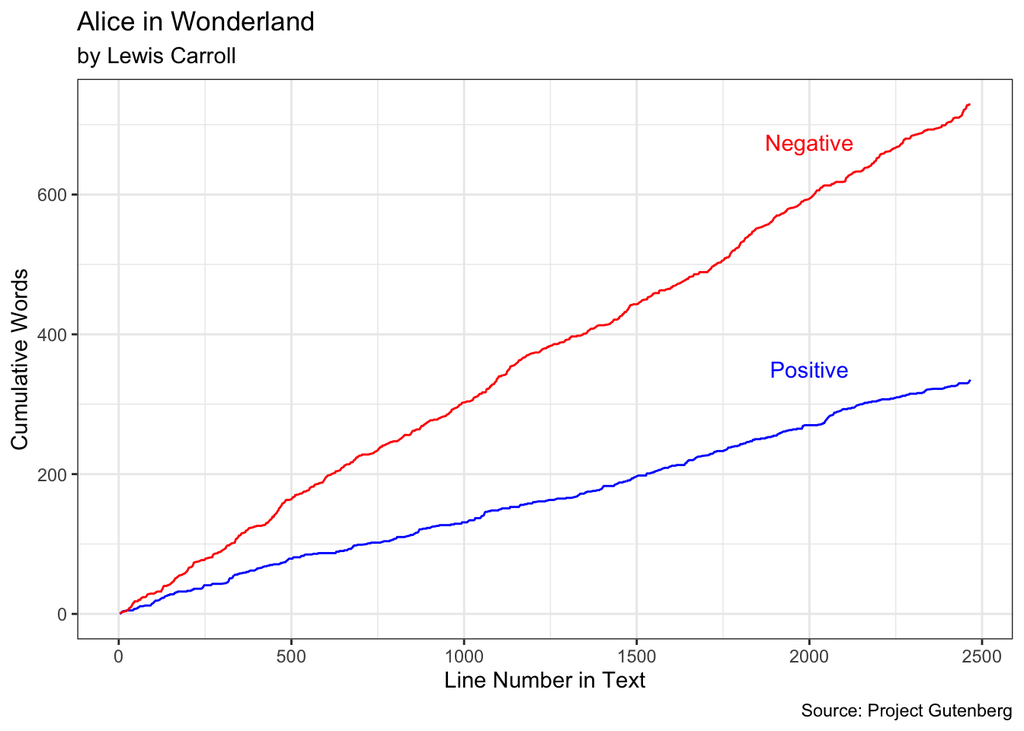

```r
#compute cumulative sentiment
alice6 <- alice5 %>%
  mutate(tot_pos=cumsum(sentiment=="positive"),
         tot_neg=cumsum(sentiment=="negative")) %>%
  group_by(line) %>%
  summarize(max_pos=max(tot_pos),
            max_neg=max(tot_neg)) %>%
  ungroup()

#plot cumulative sentiment
ggplot(data=alice6,aes(x=line)) +
  geom_line(aes(y=max_pos),color="blue") +
  geom_line(aes(y=max_neg),color="red") +
  labs(title="Alice in Wonderland",
       subtitle="by Lewis Carroll",
       x="Line Number in Text",
       y="Cumulative Words",
       caption="Source: Project Gutenberg") +
  annotate(geom="text",x=2000,y=675,label="Negative",color="red") +
  annotate(geom="text",x=2000,y=350,label="Positive",color="blue") +
  theme_bw()
```

### Değerlendirme

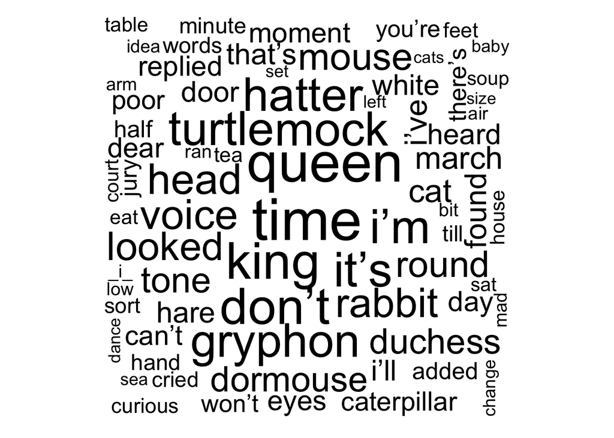

```r
#load wordcloud library
library(wordcloud)
#create wordcloud of frequencies
alice4 %>%
  filter(word!="alice") %>%
  count(word,sort=TRUE) %>%
  with(wordcloud(words=word,freq=n,
          max.words=100,random.order=FALSE))
```

```r
#Top 5 negative words
alice5 %>%
  filter(sentiment=="negative") %>%
  group_by(word) %>%
  summarize(count=n()) %>%
  ungroup() %>%
  arrange(desc(count)) %>%
  head(n=5)
```

```
## # A tibble: 5 × 2
##   word      count
##   <chr>     <int>
## 1 mock         56
## 2 poor         27
## 3 hastily      16
## 4 mad          15
## 5 anxiously    14
```

### Değerlendirme

Alice hikayesindeki en yaygın olumsuz kelime açık ara ile ‘mock’ (alay etmek) kelimesidir. Bu kelime, yerleşik ‘bing’ sözlüğü tarafından olumsuz duygu olarak atfedilmiştir. Birini alay etmek, onunla kinayeli bir şekilde dalga geçmek anlamına gelir. Sahte veya gerçek dışı olan bir nesne için ‘mock’ (sahte) kelimesi kullanılır. Dolayısıyla, olumsuz duygu atfı mantıklıdır. Ancak, bir alan uzmanı hızla, Alice hikayesindeki bir karakterin Mock Turtle (Sahte Kaplumbağa) olduğunu belirtecektir. ‘mock’ ve ‘turtle’ (kaplumbağa) kelimelerinin 3.9 Şekilde yan yana görünmesi bir tesadüf değildir. ‘Mock’ kelimesi yalnızca Mock Turtle’a atıfta bulunulduğunda kullanılır. Bu bağlamda olumsuz olarak değerlendirilmeli midir? Bu soruya cevap vermek için alan uzmanlarıyla işbirliği gerekebilir.

Mock Turtle örneğinin temel noktası bağlamın önemidir. Analizimiz, bireysel kelimelerin ötesine geçip, duyguyu doğru bir şekilde atamak için diğer kelimeler ve ifadelerle yakınlığını göz önünde bulundurmalıdır. Bununla birlikte, bireysel kelimeler bile bağlama bağlı olarak zıt duygular ifade edebilir. ‘Bad’ (kötü), ‘sick’ (hasta/kötü) ve ‘wicked’ (kötü/harika) gibi kelimeler bazı durumlarda olumsuz, diğerlerinde ise olumlu duygu ifade etmek için kullanılır. Bizim kullanımımıza sunulan çeşitli güçlü metin madenciliği araçları var, ancak dil karmaşık ve inceliklidir. Doğal dil işleme (NLP) alanı geniş olarak bu zorlukları çözmeye çalışır.

### Yanıt

Alice Harikalar Diyarında’daki anlamlı kelimelerin sıklığına dayanarak, baş karakter Alice üzerinde anlaşılabilir bir şekilde önemli bir odaklanma bulunmaktadır. Alice’in ötesinde, metin bir dizi ek karaktere atıfta bulunur. Bunlar (azalan sıklıkta) kraliçe, kral, kaplumbağa, grifon, şapka ustası, tavşan ve fareyi içerir. Kitapta görünen önemli temalar zaman, ses ve görme (bakıldı) gibi görünmektedir. Kitap ayrıca sıkça başa atıfta bulunuyor. Hikayeyi tanıyanlar için bu, kraliçenin idam takıntısı nedeniyledir!